# 05-gtseq-test5-plus-reference-baseline

9 February 2023

This is superceded by `09-reference-baseline-mixture-analysis.Rmd`

Looking at the latest iteration of the primer pool and using the reference baseline to determine whether we’re good to begin genotyping all the bycatch samples.

```r
library(tidyverse)
```

## Looking at genotypes from the .rds file

1. Do I have the read depth per locus to genotype these samples
2. Are there any loci that are mis-behaving? (>2 haplotypes per individual after filtering for read depth)

Take a look at the file produced by microhaplot from Sedna.

```r
test5 <- read_rds("../microhaplot/BFALgtseq_test5.rds")
pos.info <- read_rds("../microhaplot/BFALgtseq_test5_posinfo.rds")
```

Now that I’m attempting to run freebayes over a bunch of samples and it is running out of memory (using all 24 cores of a high-mem node on sedna), I wondering if the loci that dropped out are just because freebayes actually failed to complete the analysis and aborted?

UPDATE: yes. Now I’ve recovered 190 loci… indicating that there were memory issues that caused locus drop-out and not just invariant loci. I still wonder about the rest of the loci - there might be more optimizing to do on the Sedna/memory allocation part of this. I’ll check in with Sara and see what she’s doing.

How many total reads are accounted for?

```r
test5 %>%
  summarise(sum(depth))
```

| sum(depth) |
| --- |
| 11843768 |

```r
NA
```

```r
genos <- test5 %>%
  select(group, id, locus, haplo, depth, allele.balance, rank)


genos$locus <- gsub("_PCR_Product", "", genos$locus)
```

How many individuals in this file?

```r
genos %>%
  group_by(id) %>%
  tally()
```

| id | n |
| --- | --- |
| s1 | 1014 |
| s10 | 1236 |
| s100 | 1080 |
| s101 | 1142 |
| s102 | 1164 |
| s103 | 1749 |
| s104 | 1807 |
| s105 | 2026 |
| s106 | 1009 |
| s107 | 667 |

[output cut: 373 more lines]

```r
NA
```

Key question:

how many alleles per individual (above what depth threshold)?

```r
multi_haps <- genos %>%
  arrange(locus, id) %>%
  filter(depth > 10,
         allele.balance > 0.4) %>%
  group_by(id, locus) %>%
  add_tally() %>%
  filter(n > 2) %>%
  ungroup() %>%
  select(locus) %>%
  unique() # how many loci?
```

```r
multi_haps %>%
  left_join(., genos) %>%
  arrange(id) %>%
  filter(depth > 10,
         allele.balance > 0.4)
```

| locus | group | id | haplo | depth | allele.balance | rank |
| --- | --- | --- | --- | --- | --- | --- |
| scaffold_123_1115977 | BFAL | s1 | CGA | 32 | 1.0000000 | 1 |
| scaffold_123_1115977 | BFAL | s1 | TAC | 31 | 0.9687500 | 2 |
| scaffold_1273_1937 | BFAL | s1 | CCGAGGA | 319 | 1.0000000 | 1 |
| scaffold_214_606303 | BFAL | s1 | TTC | 43 | 1.0000000 | 1 |
| scaffold_214_606303 | BFAL | s1 | TCT | 39 | 0.9069767 | 2 |
| scaffold_229_770334 | BFAL | s1 | AC | 11 | 1.0000000 | 1 |
| scaffold_27_1646617 | BFAL | s1 | GCTG | 57 | 1.0000000 | 1 |
| scaffold_27_1646617 | BFAL | s1 | GTTG | 49 | 0.8596491 | 2 |
| scaffold_40_612943 | BFAL | s1 | TTC | 85 | 1.0000000 | 1 |
| scaffold_57_1788671 | BFAL | s1 | AAT | 37 | 1.0000000 | 1 |

[output cut: 990 more lines]

What’s the allele balance distribution for those loci?

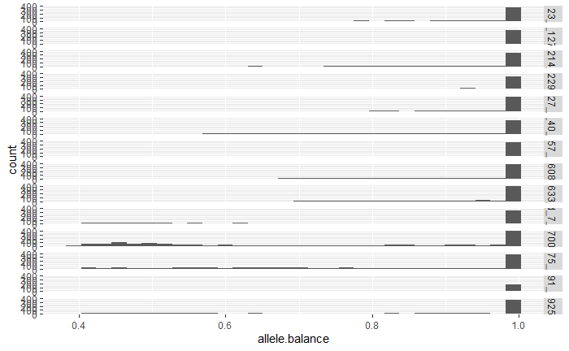

```r
multi_haps %>%
  left_join(., genos) %>%
  filter(depth > 10 & allele.balance > 0.4) %>%
  ggplot(aes(x = allele.balance)) +
  geom_histogram() +
  facet_grid(rows = vars(locus))
```

These looks funky: scaffold_75_1184494 scaffold_7_15896

The others might be okay.

How many individuals are involved? Possible they are cross-contaminated?

```r
multi_haps %>%
  left_join(., genos) %>%
  filter(depth > 10 & allele.balance > 0.4) %>%
  group_by(id, locus) %>%
  tally() %>%
  filter(n > 2) %>%
  ungroup() %>%
  group_by(id) %>%
  tally() %>%
  arrange(desc(n))
```

| id | n |
| --- | --- |
| s111 | 8 |
| s103 | 4 |
| s115 | 4 |
| s121 | 4 |
| s127 | 4 |
| s130 | 4 |
| s136 | 4 |
| s144 | 4 |
| s146 | 4 |
| s153 | 4 |

[output cut: 350 more lines]

Doesn’t look like there are any issues with the individual samples.

Now look at read depths across loci:

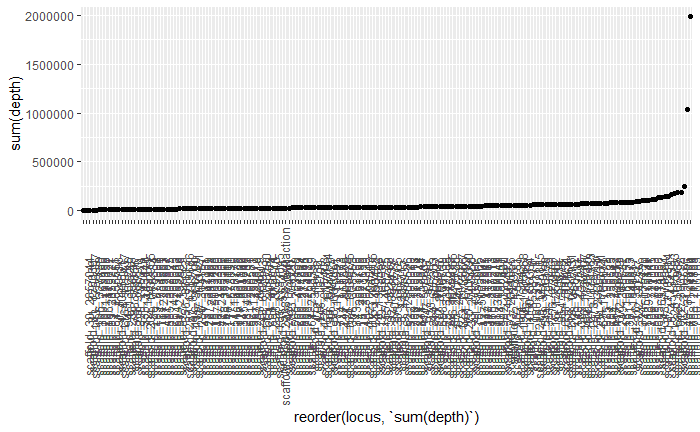

```r
# pre-filtering
genos %>%
  group_by(locus) %>%
  summarise(sum(depth)) %>%
  arrange(desc(`sum(depth)`)) %>%
  ggplot(aes(x = reorder(locus, `sum(depth)`), y = `sum(depth)`)) +
  geom_point() +
  theme(axis.text.x = element_text(angle = 90))
```

The overamplifier is also a multiple-haplotype locus. That tracks.

Seems like not that many loci in the genos output…

```r
pos.info
```

| locus | pos |
| --- | --- |
| scaffold_0_4543438_PCR_Product | 38,40,63 |
| scaffold_1_5556176_PCR_Product | 2,64 |
| scaffold_10_1333563_PCR_Product | 73 |
| scaffold_102_694013_PCR_Product | 31 |
| scaffold_1050_36334_PCR_Product | 65 |
| scaffold_1053_177405_PCR_Product | 73 |
| scaffold_1078_116737_PCR_Product | 2,78 |
| scaffold_11_3057945_PCR_Product | 2 |
| scaffold_115_2200290_PCR_Product | 4 |
| scaffold_116_1932131_PCR_Product | 2,42 |

[output cut: 180 more lines]

```r
NA
```

That is weird. There are only 53 loci that are genotyped from the ~270 when I’m looking at the reference samples as well! UPDATE: the number of loci in the new freebayes run includes 190 loci… still missing a bunch, but should do much better for pop assignment.

Filter the data for quality and go from there…

```r
genos_filt <- genos %>%
  filter(depth > 10 & allele.balance > 0.4
         & locus != "scaffold_75_1184494")
```

## Taking data through to a PCA

If that’s the case, just take a peak at a PCA for these filtered genotypes to evaluate whether there’s any obvious structure among these bycatch samples.

The format I need for the PCA is strata, indiv, markers, genotype (allele idx)

| group | indiv | locus | allele | gene_copy |
| --- | --- | --- | --- | --- |
| BFAL | s1 | scaffold_0_4543438 | GGA | 1 |
| BFAL | s1 | scaffold_1_5556176 | CC | 1 |
| BFAL | s1 | scaffold_10_1333563 | A | 1 |
| BFAL | s1 | scaffold_102_694013 | T | 1 |
| BFAL | s1 | scaffold_1050_36334 | T | 1 |
| BFAL | s1 | scaffold_1053_177405 | A | 1 |
| BFAL | s1 | scaffold_1053_177405 | G | 2 |
| BFAL | s1 | scaffold_1078_116737 | GT | 1 |
| BFAL | s1 | scaffold_11_3057945 | C | 1 |
| BFAL | s1 | scaffold_115_2200290 | C | 1 |

[output cut: 990 more lines]

```r
in_need_of_gene1 <- expanded.df %>%
  filter(gene_copy == 2 & is.na(allele)) %>%
  select(-allele)
```

```
Error in filter(., gene_copy == 2 & is.na(allele)) :
  object 'expanded.df' not found
```

```r
# look at the missing data per locus
complete_df %>%
  filter(is.na(allele)) %>%
  group_by(locus) %>%
  tally() %>%
  arrange(desc(n))
```

```
Error in filter(., is.na(allele)) : object 'complete_df' not found
```

```r
# just the loci with enough data across all samples
genos_ordered_df <- loci_keepers %>%
  left_join(., complete_df)
```

```
Error in left_join(., complete_df) : object 'loci_keepers' not found
```

```r
# first make integers of the alleles
alle_idxs <- genos_ordered_df %>%
  dplyr::select(indiv, locus, gene_copy, allele) %>%
  group_by(locus) %>%
  mutate(alleidx = as.integer(factor(allele, levels = unique(allele)))) %>%
  ungroup() %>%
  arrange(indiv, locus, alleidx) # rubias can handle NA's, so no need to change them to 0's
```

```
Error in dplyr::select(., indiv, locus, gene_copy, allele) :
  object 'genos_ordered_df' not found
```

Missing data for individuals?

```r
# if there are a total of ~53 loci, then that would be 106 alleles
# for a 50% missing data filter, we would ditch any individual with < 50 loci
ind_keepers <- alle_idxs %>%
  filter(is.na(allele)) %>%
  unique() %>%
  group_by(indiv) %>%
  tally() %>%
  arrange(desc(n)) %>%
  filter(n < 10) %>%
  select(-n)


# now select just those indivs for the PCA
keeper_df <- ind_keepers %>%
  left_join(., alle_idxs)
```

Make the df match the requirements for tidy_genomic_data

```r
long_df <- alle_idxs %>%
  select(-allele, -gene_copy) %>%
  mutate(group = "BFAL") %>%
  #left_join(., spp_indiv) %>%
  #select(species, everything()) %>%
  rename(INDIVIDUALS = indiv, STRATA = group, MARKERS = locus, GT = alleidx)
```

Genotypes should be coded with 3 integers for each alleles. 6 integers in total for the genotypes. e.g. 001002 or 111333 (for heterozygote individual). 6 integers WITH separator: e.g. 001/002 or 111/333 (for heterozygote individual). The separator can be any of these: “/”, “:”, “_“,”-“,”.”, and will be removed.

Add population information from metadata:

```r
# metadata for reference samples
meta1 <- readxl::read_xlsx("../data/BFAL_WGS_01_finalPlateMap.xlsx", sheet = "combinedPlate1And2SamplePops")

samplelist <- read_csv("../data/gtseq5_samplelist.csv")
metadata <- samplelist %>%
  left_join(., meta1, by = c("Sample_ID" = "ind_ID")) %>%
  mutate(population = ifelse(!is.na(pop), pop, population)) %>%
  mutate(population = ifelse(is.na(population), "bycatch", population)) %>%
  select(-pop)

metadata %>%
  filter(population != "bycatch")
```

| Sample_ID | Sample_Plate | Sample_Well | population | sample |
| --- | --- | --- | --- | --- |
| bycatch_plate1_NTC | BFAL_bycatch_plate1 | E06 | NTC | s45 |
| bycatch_plate2_NTC | BFAL_bycatch_plate2 | E06 | NTC | s141 |
| BFAL16-0373 | BFAL001 | A01 | Laysan | s193 |
| BFAL16-0400 | BFAL001 | B01 | Lehua | s194 |
| BFAL16-0401 | BFAL001 | C01 | Lehua | s195 |
| BFAL17-0286 | BFAL001 | D01 | Midway | s196 |
| BFAL17-0295 | BFAL001 | E01 | Tern | s197 |
| BFAL17-0319 | BFAL001 | G01 | Tern | s199 |
| BFAL17-0341 | BFAL001 | H01 | Tern | s200 |
| BFAL17-0437 | BFAL001 | A02 | Tern | s201 |

[output cut: 133 more lines]

```r
tmp <- long_df %>%
  left_join(., metadata, by = c("INDIVIDUALS" = "sample")) %>%
  select(-Sample_Well, -Sample_Plate, -Sample_ID)


long_df_strata <- tmp %>%
  mutate(STRATA = population) %>%
  select(STRATA, everything()) %>%
  select(-population)
```

```r
library("DescTools")
# create 3 digit integers from the genotypes
long_df_strata$GT3 <- Format(long_df_strata$GT, ldigits = 3, digits = 0)

head(long_df_strata)
```

| STRATA | INDIVIDUALS | MARKERS | GT | GT3 |
| --- | --- | --- | --- | --- |
| bycatch | s1 | scaffold_0_4543438 | 1 | 001 |
| bycatch | s1 | scaffold_0_4543438 | 1 | 001 |
| bycatch | s1 | scaffold_1_5556176 | 1 | 001 |
| bycatch | s1 | scaffold_1_5556176 | 1 | 001 |
| bycatch | s1 | scaffold_10_1333563 | 1 | 001 |
| bycatch | s1 | scaffold_10_1333563 | 1 | 001 |

```r
# NAs hold
# long_df %>%
#   filter(is.na(GT3))

# fix NAs
long_df0s <- long_df_strata %>%
  mutate(GT3 = ifelse(is.na(GT3), "000", GT3))

long_df0s %>%
  filter(STRATA != "bycatch")
```

| STRATA | INDIVIDUALS | MARKERS | GT | GT3 |
| --- | --- | --- | --- | --- |
| Laysan | s193 | scaffold_0_4543438 | 1 | 001 |
| Laysan | s193 | scaffold_0_4543438 | 1 | 001 |
| Laysan | s193 | scaffold_1_5556176 | 1 | 001 |
| Laysan | s193 | scaffold_1_5556176 | 2 | 002 |
| Laysan | s193 | scaffold_10_1333563 | 1 | 001 |
| Laysan | s193 | scaffold_10_1333563 | 2 | 002 |
| Laysan | s193 | scaffold_11_3057945 | 1 | 001 |
| Laysan | s193 | scaffold_11_3057945 | 1 | 001 |
| Laysan | s193 | scaffold_12_5002902 | 1 | 001 |
| Laysan | s193 | scaffold_12_5002902 | 1 | 001 |

[output cut: 990 more lines]

Now combine the GT3 column per indiv/marker:

```r
# make the genos characters and then try pasting them as strings
long_df0s$GT3 <- as.character(long_df0s$GT3)

long_df3digit <- long_df0s %>%
  group_by(INDIVIDUALS, MARKERS) %>%
  arrange(GT3, .by_group = TRUE) %>%
  summarise(GENOTYPE = toString(GT3))
# paste strings together
long_df3digit$GENOTYPE <- gsub(", ","",long_df3digit$GENOTYPE)


# add back on species identity as strata
df_for_conversion <- long_df0s %>%
  select(-GT, -GT3) %>%
  left_join(., long_df3digit) %>%
  unique() %>%
  rename(GT = GENOTYPE) %>%
  mutate(GT = ifelse(GT == "000000", NA, GT))
df_for_conversion$STRATA <- as.factor(df_for_conversion$STRATA)

# check on NAs here
df_for_conversion %>%
  filter(str_detect(INDIVIDUALS, "s"))
```

| STRATA | INDIVIDUALS | MARKERS | GT |
| --- | --- | --- | --- |
| bycatch | s1 | scaffold_0_4543438 | 001001 |
| bycatch | s1 | scaffold_1_5556176 | 001001 |
| bycatch | s1 | scaffold_10_1333563 | 001001 |
| bycatch | s1 | scaffold_11_3057945 | 001001 |
| bycatch | s1 | scaffold_12_5002902 | 001001 |
| bycatch | s1 | scaffold_14_2621198 | 001001 |
| bycatch | s1 | scaffold_14_5075430 | 001002 |
| bycatch | s1 | scaffold_15_2923659 | 001001 |
| bycatch | s1 | scaffold_15_5063205 | 001002 |
| bycatch | s1 | scaffold_16_1050955 | 001001 |

[output cut: 990 more lines]

```r
# how many loci in the df for the PCA?
df_for_conversion %>%
  select(MARKERS) %>%
  unique()
```

| MARKERS |
| --- |
| scaffold_0_4543438 |
| scaffold_1_5556176 |
| scaffold_10_1333563 |
| scaffold_11_3057945 |
| scaffold_12_5002902 |
| scaffold_14_2621198 |
| scaffold_14_5075430 |
| scaffold_15_2923659 |
| scaffold_15_5063205 |
| scaffold_16_1050955 |

[output cut: 35 more lines]

```r
NA
```

```r
library(radiator)
# use the radiator package for this conversion
genind_df <- write_genind(df_for_conversion)
```

Now that the data is a genind object, go ahead and run the PCA.

Make PCA

```r
library(adegenet)
# Allele presence absence data are extracted and NAs replaced using tab:
datasetX <- tab(genind_df, NA.method="mean") # double check that is this the appropriate method.

# make PCA
dataset_pca1 <- dudi.pca(datasetX, center = TRUE, scannf = FALSE, scale=FALSE, nf = 1000)

# colors
mycol <- colorRampPalette(c("darkgreen", "deepskyblue", "orange", "brown", "magenta", "cyan", "darkblue", "midnightblue", "blue", "dodgerblue", "darkcyan", "darkslateblue", "slateblue", "steelblue4", "skyblue", "paleturquoise4", "brown", "royalblue", "purple4", "orange", "darkorange", "darkgoldenrod", "chocolate", "tan4", "saddlebrown", "sienna", "navajowhite4", "darkgray", "black", "pink"))(55)

# plot with factor labels
pdf("pdf_outputs/BFALgtseq_test5_pca.pdf", width = 10, height = 10)
s.class(dataset_pca1$li, fac=pop(genind_df), wt = rep(1, length(pop(genind_df))), clabel = .8, grid = FALSE, cellipse = 2,
        xax=1, yax=2, col=transp(mycol,.8),
        axesel=FALSE, cstar=0, cpoint=1)
dev.off()
```

I think the PCA is very sensitive to missing data because NA is coded as 000, which would make the genotypes more similar?

## Look at the GTscore output… just because

hopefully there’s more variation that is being detected in this batch??!

```r
# read in the GTscore output

flashed <- read_tsv("../data/gtseq_test5/flashed_locusSummary.txt") %>%
  select(Locus, `Primer Reads`) %>%
  rename(flashed_reads = `Primer Reads`)
R1 <- read_tsv("../data/gtseq_test5/R1_locusSummary.txt") %>%
  select(Locus, `Primer Reads`) %>%
  rename(R1_reads = `Primer Reads`)
```

Look at those two df combined based on locus

```r
combo_df <- R1 %>%
  left_join(., flashed, by = "Locus")

combo_df %>%
  summarise(sum(R1_reads))
```

| sum(R1_reads) |
| --- |
| 14064588 |

```r
combo_df %>%
  summarise(sum(flashed_reads))
```

| sum(flashed_reads) |
| --- |
| 13395881 |

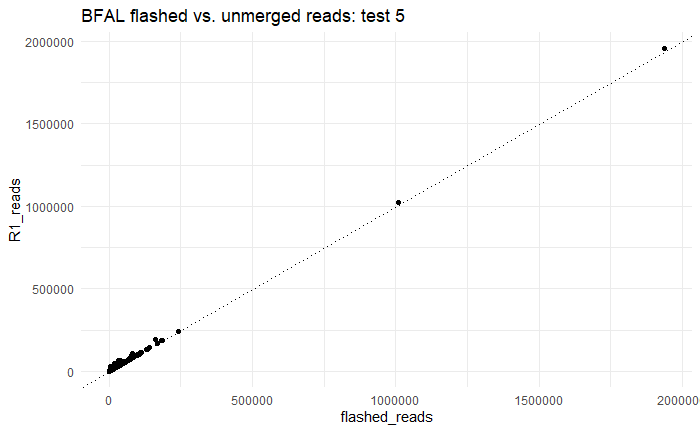

```r
combo_df %>%
  ggplot(aes(x = flashed_reads, y = R1_reads)) +
  geom_point() +
  labs(title = "BFAL flashed vs. unmerged reads: test 5") +
  geom_abline(linetype = "dotted") +
  theme_minimal()
```

| Locus | R1_reads | flashed_reads |
| --- | --- | --- |
| BFAL_scaffold_75_1184494 | 243632 | 242290 |
| BFAL_scaffold_608_211809 | 1021291 | 1009916 |
| BFAL_scaffold_700_166185 | 1955092 | 1939161 |

Crazy. Those aren’t even the loci that show up in the VCF file.

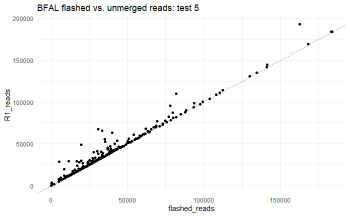

```r
# overall summary
combo_df %>%
  anti_join(., droppers) %>%
  filter(flashed_reads > 0) %>%
  ggplot(aes(x = flashed_reads, y = R1_reads)) +
  geom_point() +
  labs(title = "BFAL flashed vs. unmerged reads: test 5") +
  geom_abline(linetype = "dotted") +
  theme_minimal()
```

```r
test6 <- combo_df %>%
  anti_join(., droppers) %>%
  filter(flashed_reads > 2) %>% #don't remove the low ones bec they could make the higher ones pop up!
  #summarise(median(flashed_reads))
  arrange(flashed_reads)
```

That’s 265 loci, with mean flashed reads = 37,935, median 31,014, and ranging from 267 - 184,029.

### Self-assignment of reference baseline

One more thing to check:

```r
library(rubias)
```

| collection | indiv | scaffold_0_4543438.1 | scaffold_0_4543438.2 | scaffold_1_5556176.1 | scaffold_1_5556176.2 | scaffold_10_1333563.2 | scaffold_10_1333563.1 | scaffold_11_3057945.1 | scaffold_11_3057945.2 | scaffold_12_5002902.1 | scaffold_12_5002902.2 | scaffold_14_2621198.1 | scaffold_14_2621198.2 | scaffold_14_5075430.2 | scaffold_14_5075430.1 | scaffold_15_2923659.1 | scaffold_15_2923659.2 | scaffold_15_5063205.1 | scaffold_15_5063205.2 | scaffold_16_1050955.1 | scaffold_16_1050955.2 | scaffold_16_1254862.1 | scaffold_16_1254862.2 | scaffold_16_31673.1 | scaffold_16_31673.2 | scaffold_16_32172.1 | scaffold_16_32172.2 | scaffold_24_1490422.1 | scaffold_24_1490422.2 | … |
| --- | --- | --- | --- | --- | --- | --- | --- | --- | --- | --- | --- | --- | --- | --- | --- | --- | --- | --- | --- | --- | --- | --- | --- | --- | --- | --- | --- | --- | --- | --- |
| Laysan | s193 | 1 | 1 | 1 | 2 | 1 | 2 | 1 | 1 | 1 | 1 | 2 | 2 | 1 | 2 | 1 | 2 | 2 | 2 | 1 | 1 | 2 | 2 | 2 | 2 | 1 | 1 | 1 | 1 | … |
| Lehua | s194 | 4 | 1 | 2 | 1 | 1 | 1 | 1 | 1 | 1 | 1 | 2 | 2 | 2 | 1 | 1 | 1 | 1 | 1 | 1 | 1 | 2 | 1 | 1 | 1 | 2 | 2 | 2 | 1 | … |
| Lehua | s195 | 2 | 1 | 2 | 2 | 2 | 1 | 1 | 1 | 1 | 1 | 1 | 2 | 1 | 1 | 1 | 1 | 2 | 2 | 2 | 2 | 1 | 1 | 1 | 2 | 1 | 2 | 1 | 1 | … |
| Midway | s196 | 1 | 2 | 2 | 2 | 2 | 2 | 1 | 1 | 2 | 2 | 1 | 1 | 2 | 2 | 1 | 1 | 2 | 1 | 2 | 1 | 1 | 1 | 2 | 2 | 1 | 1 | 1 | 1 | … |
| Tern | s197 | 1 | 1 | 2 | 1 | 2 | 1 | 1 | 1 | 1 | 1 | 1 | 2 | 2 | 2 | 1 | 1 | 1 | 1 | 1 | 1 | 1 | 1 | 1 | 1 | 2 | 2 | 1 | 1 | … |
| Tern | s199 | 3 | 1 | 2 | 1 | 2 | 2 | 1 | 1 | 1 | 1 | 2 | 2 | 2 | 1 | 2 | 1 | 2 | 2 | 1 | 2 | 2 | 1 | 2 | 1 | 2 | 1 | 1 | 1 | … |
| Tern | s200 | 1 | 3 | 2 | 1 | 1 | 2 | 1 | 1 | 1 | 1 | 2 | 2 | 2 | 1 | 1 | 1 | 2 | 2 | 1 | 1 | 1 | 2 | 2 | 1 | 2 | 1 | 1 | 2 | … |
| Tern | s201 | 1 | 1 | 2 | 2 | 1 | 1 | 1 | 1 | 2 | 1 | 1 | 2 | 2 | 1 | 1 | 1 | 2 | 2 | 2 | 1 | 2 | 1 | 1 | 2 | 1 | 1 | 1 | 1 | … |
| Laysan | s206 | 2 | 1 | 1 | 1 | 1 | 2 | 1 | 1 | 2 | 2 | 1 | 1 | 2 | 1 | 2 | 1 | 2 | 1 | 1 | 1 | 1 | 2 | 2 | 2 | 1 | 1 | 2 | 1 | … |
| Tern | s207 | 1 | 1 | 2 | 1 | 1 | 2 | 1 | 1 | 1 | 1 | 2 | 2 | 2 | 1 | 1 | 1 | 2 | 2 | 1 | 1 | 1 | 1 | 1 | 1 | 2 | 2 | 1 | 1 | … |

[output cut: 125 more lines]

```r
test <- rubias::self_assign(ref_two_col, gen_start_col = 5)
```

```
Summary Statistics:

135 Individuals in Sample

45 Loci: scaffold_0_4543438.1, scaffold_1_5556176.1, scaffold_10_1333563.2, scaffold_11_3057945.1, scaffold_12_5002902.1, scaffold_14_2621198.1, scaffold_14_5075430.2, scaffold_15_2923659.1, scaffold_15_5063205.1, scaffold_16_1050955.1, scaffold_16_1254862.1, scaffold_16_31673.1, scaffold_16_32172.1…

7 Reporting Units: Laysan, Lehua, Midway, Tern, Whale-Skate, Kure, Torishima

7 Collections: Laysan, Lehua, Midway, Tern, Whale-Skate, Kure, Torishima

2.86% of allelic data identified as missing
```

| indiv | collection | repunit | inferred_collection | inferred_repunit | scaled_likelihood | log_likelihood | z_score | n_non_miss_loci | n_miss_loci | missing_loci |
| --- | --- | --- | --- | --- | --- | --- | --- | --- | --- | --- |
| s193 | Laysan | Laysan | Tern | Tern | 0.9563306 | -52.98909 | -1.98181504 | 45 | 0 |  |
| s199 | Tern | Tern | Kure | Kure | 0.9216118 | -45.34508 | 0.02924288 | 45 | 0 |  |
| s253 | Laysan | Laysan | Lehua | Lehua | 0.9614333 | -54.08450 | 5.93453966 | 45 | 0 |  |
| s265 | Tern | Tern | Kure | Kure | 0.9022820 | -45.62712 | -0.03958572 | 45 | 0 |  |
| s315 | Torishima | Torishima | Tern | Tern | 0.9267992 | -45.75910 | -0.28902872 | 45 | 0 |  |
| s339 | Kure | Kure | Tern | Tern | 0.8807639 | -56.28368 | -2.75319040 | 45 | 0 |  |
| s342 | Kure | Kure | Tern | Tern | 0.9312258 | -46.19833 | -0.39186782 | 45 | 0 |  |
| s345 | Kure | Kure | Tern | Tern | 0.9620755 | -45.93288 | -0.32971705 | 45 | 0 |  |
| s353 | Kure | Kure | Torishima | Torishima | 0.9584540 | -49.33477 | -1.75987651 | 44 | 1 |  |
| s356 | Kure | Kure | Midway | Midway | 0.9143274 | -45.29119 | -0.02382418 | 45 | 0 |  |

[output cut: 3 more lines]

```r
78/91
```

```
[1] 0.8571429
```

Ok, so the assignment with rubias actually isn’t that terrible… the PCA really doesn’t do it justice. Plus, this is with so few loci. Hopefully we can recover some additional variation??

Take a quick look to see how the mixture analysis does…

### Mixture assignment

Format everything together to avoid issues

| sample_type | repunit | collection | indiv | scaffold_0_4543438.1 | scaffold_0_4543438.2 | scaffold_1_5556176.1 | scaffold_1_5556176.2 | scaffold_10_1333563.1 | scaffold_10_1333563.2 | scaffold_11_3057945.1 | scaffold_11_3057945.2 | scaffold_12_5002902.1 | scaffold_12_5002902.2 | scaffold_14_2621198.1 | scaffold_14_2621198.2 | scaffold_14_5075430.1 | scaffold_14_5075430.2 | scaffold_15_2923659.1 | scaffold_15_2923659.2 | scaffold_15_5063205.1 | scaffold_15_5063205.2 | scaffold_16_1050955.1 | scaffold_16_1050955.2 | scaffold_16_1254862.1 | scaffold_16_1254862.2 | scaffold_16_31673.1 | scaffold_16_31673.2 | scaffold_16_32172.1 | scaffold_16_32172.2 | … |
| --- | --- | --- | --- | --- | --- | --- | --- | --- | --- | --- | --- | --- | --- | --- | --- | --- | --- | --- | --- | --- | --- | --- | --- | --- | --- | --- | --- | --- | --- | --- |
| reference | Laysan | Laysan | s193 | 1 | 1 | 1 | 2 | 2 | 1 | 1 | 1 | 1 | 1 | 2 | 2 | 2 | 1 | 1 | 2 | 2 | 2 | 1 | 1 | 2 | 2 | 2 | 2 | 1 | 1 | … |
| reference | Lehua | Lehua | s194 | 4 | 1 | 2 | 1 | 1 | 1 | 1 | 1 | 1 | 1 | 2 | 2 | 1 | 2 | 1 | 1 | 1 | 1 | 1 | 1 | 2 | 1 | 1 | 1 | 2 | 2 | … |
| reference | Lehua | Lehua | s195 | 2 | 1 | 2 | 2 | 1 | 2 | 1 | 1 | 1 | 1 | 1 | 2 | 1 | 1 | 1 | 1 | 2 | 2 | 2 | 2 | 1 | 1 | 1 | 2 | 1 | 2 | … |
| reference | Midway | Midway | s196 | 1 | 2 | 2 | 2 | 2 | 2 | 1 | 1 | 2 | 2 | 1 | 1 | 2 | 2 | 1 | 1 | 2 | 1 | 2 | 1 | 1 | 1 | 2 | 2 | 1 | 1 | … |
| reference | Tern | Tern | s197 | 1 | 1 | 2 | 1 | 1 | 2 | 1 | 1 | 1 | 1 | 1 | 2 | 2 | 2 | 1 | 1 | 1 | 1 | 1 | 1 | 1 | 1 | 1 | 1 | 2 | 2 | … |
| reference | Tern | Tern | s199 | 3 | 1 | 2 | 1 | 2 | 2 | 1 | 1 | 1 | 1 | 2 | 2 | 1 | 2 | 2 | 1 | 2 | 2 | 1 | 2 | 2 | 1 | 2 | 1 | 2 | 1 | … |
| reference | Tern | Tern | s200 | 1 | 3 | 2 | 1 | 2 | 1 | 1 | 1 | 1 | 1 | 2 | 2 | 1 | 2 | 1 | 1 | 2 | 2 | 1 | 1 | 1 | 2 | 2 | 1 | 2 | 1 | … |
| reference | Tern | Tern | s201 | 1 | 1 | 2 | 2 | 1 | 1 | 1 | 1 | 2 | 1 | 1 | 2 | 1 | 2 | 1 | 1 | 2 | 2 | 2 | 1 | 2 | 1 | 1 | 2 | 1 | 1 | … |
| reference | Laysan | Laysan | s206 | 2 | 1 | 1 | 1 | 2 | 1 | 1 | 1 | 2 | 2 | 1 | 1 | 1 | 2 | 2 | 1 | 2 | 1 | 1 | 1 | 1 | 2 | 2 | 2 | 1 | 1 | … |
| reference | Tern | Tern | s207 | 1 | 1 | 2 | 1 | 2 | 1 | 1 | 1 | 1 | 1 | 2 | 2 | 1 | 2 | 1 | 1 | 2 | 2 | 1 | 1 | 1 | 1 | 1 | 1 | 2 | 2 | … |

[output cut: 125 more lines]

```r
# run mixture assignment with rubias
mix_assign <- infer_mixture(reference = ref, mixture = mix, gen_start_col = 5, method = "MCMC", reps = 2000, burn_in = 100)
```

One key caveat here is that the repunits should probably be reformulated to reflect the biological divisions (e.g., some of these pops are genetically very very similar)

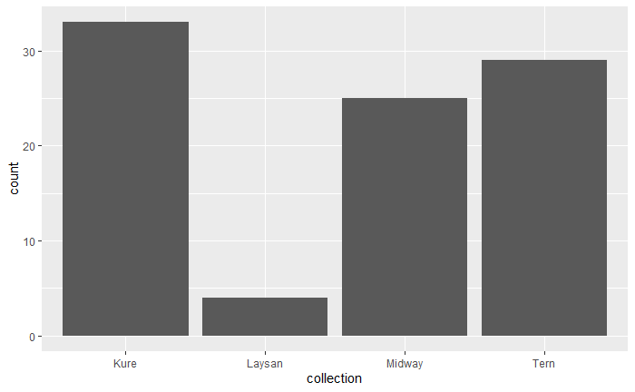

| indiv | locus | gene_copy | allele | alleidx |
| --- | --- | --- | --- | --- |
| s1 | scaffold_0_4543438 | 1 | GGA | 1 |
| s1 | scaffold_0_4543438 | 2 | GGA | 1 |
| s1 | scaffold_1_5556176 | 1 | CC | 1 |
| s1 | scaffold_1_5556176 | 2 | CC | 1 |
| s1 | scaffold_10_1333563 | 1 | A | 1 |
| s1 | scaffold_10_1333563 | 2 | A | 1 |
| s1 | scaffold_11_3057945 | 1 | C | 1 |
| s1 | scaffold_11_3057945 | 2 | C | 1 |
| s1 | scaffold_12_5002902 | 1 | T | 1 |
| s1 | scaffold_12_5002902 | 2 | T | 1 |

[output cut: 990 more lines]

165 alleles in 45 loci.

| locus |
| --- |
| scaffold_0_4543438 |
| scaffold_1_5556176 |
| scaffold_10_1333563 |
| scaffold_11_3057945 |
| scaffold_12_5002902 |
| scaffold_14_2621198 |
| scaffold_14_5075430 |
| scaffold_15_2923659 |
| scaffold_15_5063205 |
| scaffold_16_1050955 |

[output cut: 35 more lines]

## Next steps

Okay. The locus drop-out is not awesome, but I’ll keep investigating that in the coming days. In the meantime, I’ll have Claire run the rest of the albatross bycatch samples using a panel that has just the 2 crazy overamplifiers plus the one which has horrible multiple haplotype issues removed.

Make that output file:

```r
prior <- read_csv("csv_outputs/BFALgtseq_test5_primer_cherrypick.csv")
```

```r
cherrypick6 <- test6 %>%
  left_join(., prior) %>%
  mutate(`Destination Plate` = "BFALgtseq_test6") %>%
  select(`Plate Name`, `Well Position`, Locus, `Destination Plate`, `Destination Well`, new_ul) %>%
  rename(`Source Plate` = `Plate Name`, `Source Well` = `Well Position`, Volume = new_ul)
```

| Source Plate | Source Well | Locus | Destination Plate | Destination Well | Volume |
| --- | --- | --- | --- | --- | --- |
| BFALgtseqPlate3 | E04 | scaffold_289_1045900 | BFALgtseq_test6 | NA | 5.00 |
| BFALgtseqPlate1 | A08 | scaffold_30_2857044 | BFALgtseq_test6 | NA | 5.00 |
| BFALgtseqPlate4 | F06 | scaffold_1180_121024 | BFALgtseq_test6 | NA | 5.00 |
| BFALgtseqPlate3 | G03 | scaffold_273_874676 | BFALgtseq_test6 | NA | 4.00 |
| BFALgtseqPlate2 | B12 | scaffold_213_145098 | BFALgtseq_test6 | NA | 1.25 |
| BFALgtseqPlate2 | D08 | scaffold_156_1569501 | BFALgtseq_test6 | NA | 1.25 |
| BFALgtseqPlate3 | A08 | scaffold_393_573517 | BFALgtseq_test6 | NA | 3.33 |
| BFALgtseqPlate3 | A09 | scaffold_452_89307 | BFALgtseq_test6 | NA | 2.50 |
| BFALgtseqPlate4 | G06 | scaffold_1226_115655 | BFALgtseq_test6 | NA | 1.25 |
| BFALgtseqPlate2 | D07 | scaffold_143_1756997 | BFALgtseq_test6 | NA | 3.33 |

[output cut: 252 more lines]